# Autogenous - quality control.

Luciano V Cosme

2023-10-27

## 1. Getting started: R libraries and software for QC

## 1.1 R libraries and software

```r
library(tidyverse)
library(here)
library(dplyr)
library(ggplot2)
library(colorout)
library(extrafont)
library(reticulate)
library(scales)
library(stringr)
library(grid)
library(flextable)
library(devtools)
library(readr)
library(purrr)
library(ggtext)
library(ggvenn)
library(data.table)
library(RColorBrewer)
library(ggrepel)
library(OutFLANK)
library(vcfR)
```

## 1.2 Check directory structure for the project

**Note:** make sure you download the raw data and place it in a new directory. You can check the directory structure using a tool called [Tree](https://atom.io/packages/ascii-tree).

```bash
# check all the Tree options with the command in your terminal: man tree
tree -L 2 -d --charset=ascii . # -L set the directory depth to show; the flag -d tells tree to return directories only. and the period at the end tells tree to use the current directory; --charset=ascii is to show nicely here.
# if you want to see the files you can use the code below.
# tree --dirsfirst .
```

```
|-- data
|   |-- files
|   |-- genome
|   |-- genotype_calls
|   `-- raw_data
|-- output
`-- scripts
    |-- functions_scripts
    `-- markdown_files
```

## 1.3 Download software for quality control

I used PLINK v2.00a3.3 64-bit (3 Jun 2022) for all the analysis. However, the Affymetrix software does not export the files directly into a format we can import into Plink2. Therefore, we need first to use Plink 1.9 to convert the `vcf` or `.ped` and `.map` file format to `.bed`, `.bin`, and `.fam`. You can install it with `conda`. You can download [Miniconda](https://conda.io/projects/conda/en/latest/user-guide/install/download.html) or [Anaconda](https://www.anaconda.com/). `conda install -c bioconda plink2`. If you have problems, you can also get it from [GitHub](https://github.com/chrchang/plink-ng), and compile it for your OS (both versions, 1.9 and 2). Please check [Marees et. al, 2018](https://doi.org/10.1002/mpr.1608) for more information about quality control using Plink 1.9. I used some of their code for quality control, and their general guidelines.

Check your Plink2 version.

```bash
plink2 --version
```

```
## PLINK v2.00a3.3 64-bit (3 Jun 2022)
```

**First check if the data is in the correct location:**

```bash
ls data/genotype_calls/* # we use * to truncate the name of the file showing all files
```

```
## data/genotype_calls/autogenous.log
## data/genotype_calls/autogenous.vcf
```

Note about the bash multiline comments.  
Since we will use the Plink command with one option per line separated by backslash `/` , and not one single line command, we add comments using `` # ` `` to open and `` ` `` to close.  
For example, we can split the `plink2 –version` into a multiline command with a comment.

```bash
plink2 `# this still works` \
--version
```

```
## PLINK v2.00a3.3 64-bit (3 Jun 2022)
```

## 2. The data

I prepared the data with the families and individual ids. I also set the reference alleles to match the AlbF3 genome assembly

We can check how many sample names we have in our vcf

```bash
# make sure you have all the .CEL samples in your family file
bcftools query -l data/genotype_calls/autogenous.vcf | wc -l
```

```
##       61
```

## 2.1 Use Plink2 to convert to bed format

```bash
plink2 \
--allow-extra-chr \
--vcf data/genotype_calls/autogenous.vcf \
--const-fid \
--make-bed \
--exclude data/files/albopictus_SNPs_fail_segregation.txt \
--fa data/genome/albo.fasta.gz \
--ref-from-fa 'force' `# sets REF alleles when it can be done unambiguously, we use force to change the alleles` \
--out output/quality_control/file1 \
--silent;
# --keep-allele-order \ if you use Plink 1.9
grep "variants" output/quality_control/file1.log; # to get the number of variants from the log file.
```

```
## --vcf: 131048 variants scanned.
## 131048 variants loaded from output/quality_control/file1-temporary.pvar.zst.
## --exclude: 129381 variants remaining.
## 129381 variants remaining after main filters.
## --ref-from-fa force: 0 variants changed, 129381 validated.
```

Check the fam file

```bash
# Check head of the data
head output/quality_control/file1.fam
```

```
## 0    306_MAN_USA.CEL 0   0   0   -9
## 0    307_MAN_USA.CEL 0   0   0   -9
## 0    308_MAN_USA.CEL 0   0   0   -9
## 0    309_MAN_USA.CEL 0   0   0   -9
## 0    310_MAN_USA.CEL 0   0   0   -9
## 0    311_MAN_USA.CEL 0   0   0   -9
## 0    312_MAN_USA.CEL 0   0   0   -9
## 0    313_MAN_USA.CEL 0   0   0   -9
## 0    314_MAN_USA.CEL 0   0   0   -9
## 0    315_MAN_USA.CEL 0   0   0   -9
```

```bash
head -n 5 data/files/meta_data.txt
```

```
## Sample Filename  Family_ID   Individual_ID   Father_ID   Mother_ID   Sex Affection Status
## 306_MAN_USA.CEL  MAN 306 0   0   0   -9
## 307_MAN_USA.CEL  MAN 307 0   0   0   -9
## 308_MAN_USA.CEL  MAN 308 0   0   0   -9
## 309_MAN_USA.CEL  MAN 309 0   0   0   -9
```

## 2.2 Use R to update the .fam file

Import the fam file we use with Axiom Suite

```r
# the order of the rows in this file does not matter
samples <-
  read.delim(
    file   = here(
      "data",
      "files",
      "meta_data.txt"
    ),
    header = TRUE
  )
head(samples)
```

```
##   Sample.Filename Family_ID Individual_ID Father_ID Mother_ID Sex
## 1 306_MAN_USA.CEL       MAN           306         0         0   0
## 2 307_MAN_USA.CEL       MAN           307         0         0   0
## 3 308_MAN_USA.CEL       MAN           308         0         0   0
## 4 309_MAN_USA.CEL       MAN           309         0         0   0
## 5 310_MAN_USA.CEL       MAN           310         0         0   0
## 6 311_MAN_USA.CEL       MAN           311         0         0   0
##   Affection.Status
## 1               -9
## 2               -9
## 3               -9
## 4               -9
## 5               -9
## 6               -9
```

Import .fam file we created once we created the bed file using Plink2

```r
# The fam file is the same for both data sets with the default or new priors
fam1 <-
  read.delim(
    file   = here(
      "output", "quality_control", "file1.fam"
    ),
    header = FALSE,

  )
head(fam1)
```

```
##   V1              V2 V3 V4 V5 V6
## 1  0 306_MAN_USA.CEL  0  0  0 -9
## 2  0 307_MAN_USA.CEL  0  0  0 -9
## 3  0 308_MAN_USA.CEL  0  0  0 -9
## 4  0 309_MAN_USA.CEL  0  0  0 -9
## 5  0 310_MAN_USA.CEL  0  0  0 -9
## 6  0 311_MAN_USA.CEL  0  0  0 -9
```

We can merge the tibbles.

```r
# Extract the number part from the columns
fam1_temp <- fam1 |>
  mutate(num_id = as.numeric(str_extract(V2, "^\\d+")))

samples_temp <- samples |>
  mutate(num_id = as.numeric(str_extract(Sample.Filename, "^\\d+")))

# Perform the left join using the num_id columns and keep the order of fam1
df <- fam1_temp |>
  dplyr::left_join(samples_temp, by = "num_id") |>
  dplyr::select(-num_id) |>
  dplyr::select(8:13)

# check the data frame
head(df)
```

```
##   Family_ID Individual_ID Father_ID Mother_ID Sex Affection.Status
## 1       MAN           306         0         0   0               -9
## 2       MAN           307         0         0   0               -9
## 3       MAN           308         0         0   0               -9
## 4       MAN           309         0         0   0               -9
## 5       MAN           310         0         0   0               -9
## 6       MAN           311         0         0   0               -9
```

We can check how many samples we have in our file

```r
nrow(df)
```

```
## [1] 61
```

Before you save the new fam file, you can change the original file to a different name, to compare the order later. If you want to repeat the steps above after you saving the new file1.fam, you will need to import the vcf again.

```r
# Save and override the .fam file for dp
write.table(
  df,
  file      = here(
    "output", "quality_control", "file1.fam"
  ),
  sep       = "\t",
  row.names = FALSE,
  col.names = FALSE,
  quote     = FALSE
)
```

Check the new .fam file to see if has the order and the sample attributes we want.

```bash
# you can open the file on a text editor and double check the sample order and information.
head -n 5 output/quality_control/file1.fam
```

```
## MAN  306 0   0   0   -9
## MAN  307 0   0   0   -9
## MAN  308 0   0   0   -9
## MAN  309 0   0   0   -9
## MAN  310 0   0   0   -9
```

## 2.3 Checking the number of samples and localities

```bash
awk '{print $1}' output/quality_control/file1.fam | sort | uniq -c | awk '{print $2, $1}'
```

```
## AUT 29
## MAN 10
## NEW 22
```

In Linux/Unix we have 3 `I/O streams`: Standard input (`stdin`) - this is the file handle that your process reads to get information from you.  
Standard output (`stdout`) - your process writes conventional output to this file handle.  
Standard error (`sterr`) - your process writes diagnostic output to this file handle.  
Most programs need to read input, write output, and log errors, so `stdin`, `stdout`, and `stderr` are predefined as a programming convenience.  
An easy way to access any file is by using the unique file descriptor number associated with it. In the case of these streams, there are unique values assigned to each one of them:  
0: `stdin`  
1: `stdout`  
2: `stderr`

## 3. Quality control steps

## 3.1 Missingness

```bash
plink2 \
--allow-extra-chr \
--bfile output/quality_control/file1 \
--geno 0.2                `# we set genotype missiningness to 20% with this option` \
--make-bed \
--out output/quality_control/file2 \
--silent \
--missing;                 # --missing produces sample-based and variant-based missing data reports. If run with --within/--family, the variant-based report is stratified by cluster.
grep "variants" output/quality_control/file2.log
```

```
## 129381 variants loaded from output/quality_control/file1.bim.
## --geno: 2271 variants removed due to missing genotype data.
## 127110 variants remaining after main filters.
```

Make plot

```r
#   ____________________________________________________________________________
#   import individual missingness                                           ####
indmiss <-                                              # name of the data frame we are creating
  read.delim(                                           # use function read table
    file   = here(
      "output", "quality_control", "file2.smiss"
    ),                                                  # we use library here to import file2.imiss from data/QC
    header = TRUE                                       # we do have headers in our file
  )
#   ____________________________________________________________________________
#   import SNP missingness                                                  ####
snpmiss <-
  read.delim(
    file   = here(
      "output", "quality_control", "file2.vmiss"
    ),
    header = TRUE
  )
#
```

Plot individual missingness

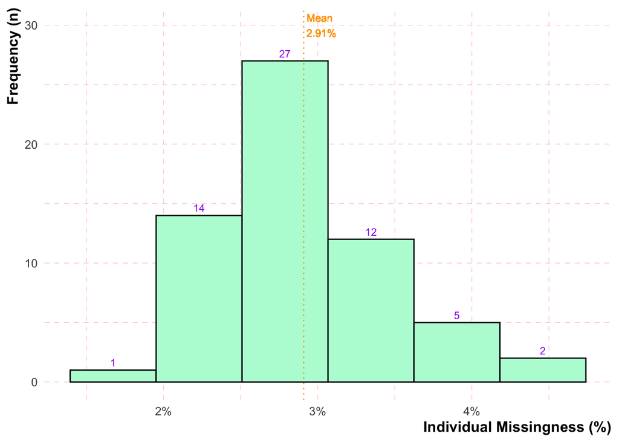

```r
# load plotting theme
source(
  here(
    "scripts", "analysis", "my_theme2.R"
  )
)

ggplot( # Start a ggplot object with the data and aesthetic mappings
  indmiss,
  aes(
    x = F_MISS
  )
) +
  geom_histogram( # Add a histogram layer
    color            = "black",
    fill             = "#B6FAD7",
    bins             = 6
  ) +
  geom_text(
    # Add text labels for bin counts
    stat             = "bin",
    aes(
    label = after_stat(count)
  ),
    vjust            = -0.5,
    color            = "purple",
    size             = 3,
    bins             = 6
  ) +
  geom_vline(
    # Add a vertical line at the mean of F_MISS
    aes(
    xintercept = mean(F_MISS)),
    color            = "orange",
    linetype         = "dotted",
    linewidth        = .5
  ) +
  geom_text(
    # Add a text label for the mean of F_MISS
    aes(
      x = mean(F_MISS),
      y = 30,
      label = paste0(
        "Mean \n",
        scales::percent(mean(F_MISS),
          accuracy = 0.01
        )
      )
    ),
    size = 3,
    color = "orange",
    hjust = -.1
  ) +
  labs( # Add axis labels
    x                = "Individual Missingness (%)",
    y                = "Frequency (n)"
  ) +
  my_theme() +
  scale_x_continuous( # Scale the x-axis to display percentages
    labels           = scales::percent,
    n.breaks         = 6
  )
```

```r
#
# save the plot
ggsave(
  here(
    "output", "quality_control", "figures" , "individual_missingness.pdf"
  ),
  width              = 7,
  height             = 5,
  units              = "in"
)
```

The function my_theme() that we imported above

```r
# Define a function to customize the theme
my_theme <- function() {
  theme_minimal(base_size = 12, base_family = "") +
    theme(
      panel.grid.major = element_line(
        linetype = "dashed",
        linewidth = 0.2,
        color = "pink"
      ),
      panel.grid.minor = element_line(
        linetype = "dashed",
        linewidth = 0.2,
        color = "pink"
      ),
      # Customize the x-axis label
      axis.title.x = element_text(
        angle          = 0,
        hjust          = 1,
        face           = "bold"
      ),
      # Customize the y-axis label
      axis.title.y = element_text(
        angle          = 90,
        hjust          = 1,
        face           = "bold"
      )
    )
}
# we can save the function to source it later
dump(                                                    # check ?dump for more information
  "my_theme",                                            # the object we want to save
  here(
    "scripts", "analysis", "my_theme2.R")                # use here to save it our function as .R
)
```

Plot variant missingness

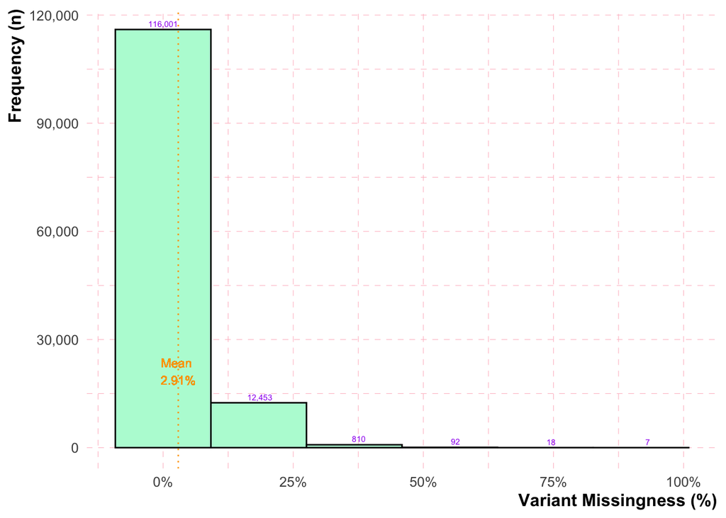

```r
# This plot takes a while to compute
# This code creates a histogram from the indmiss data set using the F_MISS column.
# ggplot builds a histogram of individual missingness data
ggplot(
  snpmiss,
  aes(
    x = F_MISS
  )
) +
  geom_histogram(
    color = "black",
    fill = "#B6FAD7",
    bins = 6
  ) +
  stat_bin(
    geom = "text",
    aes(
      label = format(
        after_stat(count),
        big.mark = ",",
        scientific = FALSE
      )
    ),
    vjust = -0.5,
    color = "purple",
    size = 2,
    bins = 6
  ) +
  geom_vline(
    aes(
      xintercept = mean(F_MISS)
    ),
    color = "orange",
    linetype = "dotted",
    linewidth = 0.5
  ) +
  geom_text(
    aes(
      x = mean(F_MISS),
      y = 16000,
      label = paste0(
        "Mean \n",
        scales::percent(mean(F_MISS),
          accuracy = 0.01
        )
      )
    ),
    size = 3,
    color = "orange",
    # hjust = 1.5,
    vjust = -.2
  ) +
  labs(
    x = "Variant Missingness (%)",
    y = "Frequency (n)"
  ) +
  # theme_minimal(
  #   base_size = 12,
  #   base_family = "Roboto Condensed"
  # ) +
  scale_x_continuous(
    labels = scales::percent,
    n.breaks = 6
  ) +
  scale_y_continuous(
    labels = scales::label_comma(),
    n.breaks = 5
  ) +
  my_theme()
```

```r
# save the plot
ggsave(
  here(
    "output", "quality_control", "figures", "SNPs_missingness.pdf"
  ),
  width  = 7,
  height = 5,
  units  = "in"
)
```

Remove individuals missing more than 20% of SNPs. You can use the threshold you want, change the flag –mind

```bash
plink2 \
--allow-extra-chr \
--bfile output/quality_control/file2 \
--mind 0.2               `# here we set the individual missingness threshold of 20%`\
--make-bed \
--out output/quality_control/file3 \
--silent;
grep "samples\|variants" output/quality_control/file3.log
```

```
## 61 samples (25 females, 26 males, 10 ambiguous; 61 founders) loaded from
## 127110 variants loaded from output/quality_control/file2.bim.
## 0 samples removed due to missing genotype data (--mind).
## 61 samples (25 females, 26 males, 10 ambiguous; 61 founders) remaining after
```

## 3.2 Minor allele frequency

First lets make a plot of the MAF. First, we estimate the allele frequency with Plink.

```bash
plink2 \
--allow-extra-chr \
--bfile output/quality_control/file3 \
--freq \
--out output/quality_control/MAF_check \
--silent
```

Then we plot it with ggplot.

```r
#   ____________________________________________________________________________
#   Import MAF data                                                         ####
maf_freq <-
  read.delim(
    here(
      "output", "quality_control", "MAF_check.afreq"
    ),
    header = TRUE
  )
```

Make MAF plot

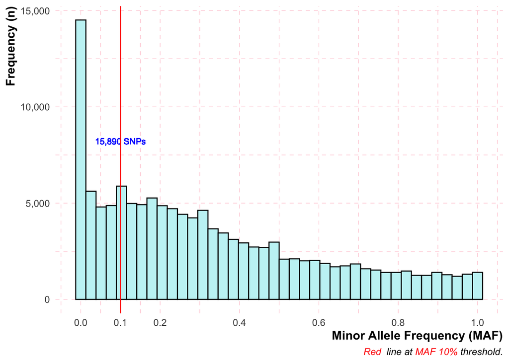

```r
#   ____________________________________________________________________________
#   make the plot                                                           ####
ggplot(
  maf_freq,
  aes(ALT_FREQS)
) +
  geom_histogram(
    colour = "black",
    fill = "#C4F3F5",
    bins = 40
  ) +
  labs(
    x = "Minor Allele Frequency (MAF)",
    y = "Frequency (n)",
    caption = "<span style='color:red;'><i>Red</i></span> <span style='color:black;'><i>line at</i></span><span style='color:red;'><i> MAF 10%</i></span><span style='color:black;'><i> threshold</i></span>."
  ) +
  geom_text(
    aes(
      x = .1,
      y = 8000,
      label = paste0("15,890 SNPs")
    ),
    size = 3,
    color = "blue",
    vjust = -.2
  ) +
  geom_vline(xintercept = 0.1, color = "red") +
  my_theme() +
  theme(plot.caption = element_markdown()) +
  scale_y_continuous(label = scales::number_format(big.mark = ",")) +
  scale_x_continuous(breaks = c(0, 0.1, 0.2, 0.4, 0.6, 0.8, 1))
```

```r
#   ____________________________________________________________________________
#   save the plot                                                           ####
ggsave(
  here(
    "output", "quality_control", "figures", "MAF.pdf"
  ),
  width  = 5,
  height = 4,
  units  = "in"
)
```

Now we apply the MAF filter.

```bash
# We will use MAF of 10%
plink2 \
--allow-extra-chr \
--bfile output/quality_control/file3 \
--maf 0.01 \
--make-bed \
--out output/quality_control/file4 \
--silent;
grep "variants" output/quality_control/file4.log
```

```bash
mkdir -p output/quality_control/hardy;
cp output/quality_control/file4.* output/quality_control/hardy/
```

## 3.3 HWE test

Now we can run the HWE test. However, we will need to apply the SNP missingness again for each population. If we do not, the HWE will vary widely. With the bash script below, we will create a new file for each population, run the HWE test with HWE p value <1e‐6 (HWE p value <1e‐6). Then, we ask Plink to generate a list of SNPs that passed the test for each population.

```bash
for fam in $(awk '{print $1}' output/quality_control/hardy/file4.fam | sort | uniq);
do
echo $fam | \
plink2 \
--allow-extra-chr \
--silent \
--keep-allele-order \
--bfile output/quality_control/hardy/file4 \
--keep-fam /dev/stdin \
--make-bed \
--out output/quality_control/hardy/$fam \
--hwe 0.000001 \
--geno 0.1 \
--write-snplist; \
done
```

Next, we use “cat” and “`awk`” to concatenate the SNP list from all populations, and remove duplicates. Once we have a list of SNPs that passed the test for each population, we can use Plink to create a new bed file keeping only the SNPs that passed the test in each population. First, lets get the list of SNPs, and count how many passed:

```bash
cat output/quality_control/hardy/*.snplist | awk '!a[$0]++' > output/quality_control/passed_hwe.txt;
wc -l output/quality_control/passed_hwe.txt
```

[output not shown]

How many variants we had before

```bash
cat output/quality_control/file4.bim | awk '{print $2}'| awk '!a[$0]++' | wc -l
```

```
##   111220
```

Variants not passing HWE test

```r
111220 - 110353
```

```
## [1] 867
```

Remove the SNPs that failed

```bash
plink2 \
--allow-extra-chr \
--bfile output/quality_control/file4 \
--extract output/quality_control/passed_hwe.txt \
--make-bed \
--out output/quality_control/file4a \
--silent;
grep "variants" output/quality_control/file4a.log
```

## 3.4 LD pruning

```bash
plink2 \
--allow-extra-chr \
--bfile output/quality_control/file4a \
--indep-pairwise 5 1 0.1 \
--out output/quality_control/indepSNP \
--silent;
grep 'pairwise\|variants\|samples' output/quality_control/indepSNP.log
```

## 3.6 Heterozygosity

```bash
plink2 \
--allow-extra-chr \
--bfile output/quality_control/file4a \
--extract output/quality_control/indepSNP.prune.in \
--het \
--out output/quality_control/R_check \
--silent;
grep 'variants' output/quality_control/R_check.log
```

[output not shown]

Plot it

```r
#   ____________________________________________________________________________
#   find individuals with high heterozygosity                              ####
# import the data from Plink
het <- read.delim(
  here(
    "output", "quality_control", "R_check.het"
  ),
  head = TRUE
)
#
# check head of the file
colnames(het)
```

```
## [1] "X.FID"  "IID"    "O.HOM." "E.HOM." "OBS_CT" "F"
```

Estimate het

```r
# create a column named HET_RATE and calculate the heterozygosity rate
het$HET_RATE <- (het$"OBS_CT" - het$"O.HOM") / het$"OBS_CT"
#
# use subset function to get values deviating from 4sd of the mean heterozygosity rate.
het_fail <-
  subset(
    het, (het$HET_RATE < mean(
      het$HET_RATE
    ) - 4 * sd(
      het$HET_RATE
    )) |
      (het$HET_RATE > mean(
        het$HET_RATE
      ) + 4 * sd(
        het$HET_RATE
      ))
  )
#
# get the list of individuals that failed our threshold of 4sd from the mean.
het_fail$HET_DST <-
  (het_fail$HET_RATE - mean(
    het$HET_RATE
  )) / sd(
    het$HET_RATE
  )
```

Save the files to use with Plink

```r
#   ____________________________________________________________________________
#   save the data to use with Plink2                                        ####
#
write.table(
  het_fail,
  here(
    "output", "quality_control", "fail-het-qc.txt"
  ),
  row.names = FALSE
)
```

Make plot

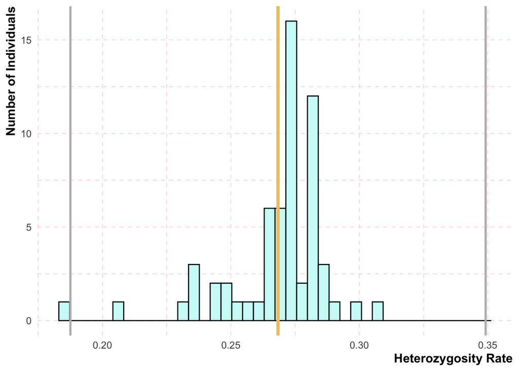

```r
#   ____________________________________________________________________________
#   make a heterozygosity plot                                              ####
#
ggplot(
  het,
  aes(
    HET_RATE
  )
) +
  geom_histogram(
    colour           = "black",
    fill             = "#CDFAF8",
    bins             = 40
  ) +
  labs(
    x                = "Heterozygosity Rate",
    y                = "Number of Individuals"
  ) +
  geom_vline(
    aes(
      xintercept     = mean(
        HET_RATE
      )
    ),
    col              = "#F2C46F",
    linewidth        = 1.5
  ) +
  geom_vline(
    aes(
      xintercept     = mean(
        HET_RATE
      ) + 4 * sd(
        HET_RATE
      )
    ),
    col              = "#BFB9B9",
    linewidth        = 1
  ) +
  geom_vline(
    aes(
      xintercept     = mean(
        HET_RATE
      ) - 4 * sd(
        HET_RATE
      )
    ),
    col              = "#BFB9B9",
    linewidth        = 1
  ) +
  my_theme() +
  scale_y_continuous(
    labels           = comma
  )
```

```r
#   ____________________________________________________________________________
#   save the heterozygosity plot                                            ####
ggsave(
  here(
    "output", "quality_control", "figures", "Heterozygosity.pdf"
  ),
  width  = 5,
  height = 4,
  units  = "in"
)
```

```bash
sed 's/"// g' output/quality_control/fail-het-qc.txt | awk '{print$1, $2}'> output/quality_control/het_fail_ind.txt;
echo 'How many mosquitoes we need to remove from our data set:';
cat output/quality_control/het_fail_ind.txt | tail -n +2 | wc -l;
echo 'Which mosquitoes we have to remove:';
tail -n +2 output/quality_control/het_fail_ind.txt
```

```
## How many mosquitoes we need to remove from our data set:
##        1
## Which mosquitoes we have to remove:
## AUT 399
```

Next, we will remove these mosquitoes from our data set using Plink:

```bash
plink2 \
--allow-extra-chr \
--bfile output/quality_control/file4a \
--remove output/quality_control/het_fail_ind.txt \
--make-bed \
--out output/quality_control/file5 \
--silent;
grep 'variants\|samples' output/quality_control/file5.log
```

## 3.7 Relatedness

Check for cryptic relatedness. Check Plink2 documentation https://www.cog-genomics.org/plink/2.0/distance You can download King directly https://www.kingrelatedness.com/manual.shtml or check their manuscript https://www.ncbi.nlm.populations.gov/pmc/articles/PMC3025716/pdf/btq559.pdf From Plink2 documentation: “Note that KING kinship coefficients are scaled such that duplicate samples have kinship 0.5, not 1. First-degree relations (parent-child, full siblings) correspond to ~0.25, second-degree relations correspond to ~0.125, etc. It is conventional to use a cutoff of ~0.354 (the geometric mean of 0.5 and 0.25) to screen for monozygotic twins and duplicate samples, ~0.177 to add first-degree relations, etc.” There two options. One is to run only –make-king and another one is to use –make-king-table We will use the threshold of 0.354 and create a table.

```bash
# Plink2 will create a file with extension .king
plink2 \
--allow-extra-chr \
--bfile output/quality_control/file5 \
--extract output/quality_control/indepSNP.prune.in \
--make-king-table rel-check \
--king-table-filter 0.354 \
--out output/quality_control/file5a \
--silent;
grep 'variants\|samples' output/quality_control/file5a.log
```

[output not shown]

Check the individuals that did not pass our filtering.

```bash
head output/quality_control/file5a.kin0
```

```
## #FID1    IID1    FID2    IID2    NSNP    HETHET  IBS0    KINSHIP
```

No related individulas

We want to remove one of the individuals of the pairs.

```bash
plink2 \
--allow-extra-chr \
--bfile output/quality_control/file5 \
--extract output/quality_control/indepSNP.prune.in \
--make-king triangle bin \
--out output/quality_control/file6 \
--silent;
grep 'variants\|samples' output/quality_control/file6.log
```

```
## 60 samples (24 females, 26 males, 10 ambiguous; 60 founders) loaded from
## 110353 variants loaded from output/quality_control/file5.bim.
## --extract: 41620 variants remaining.
## 41620 variants remaining after main filters.
## --make-king pass 1/1: Scanning for rare variants... done.
## 1240 variants handled by initial scan (40380 remaining).
## --make-king: 41620 variants processed.
```

```bash
plink2 \
--allow-extra-chr \
--bfile output/quality_control/file5 \
--king-cutoff output/quality_control/file6 0.354 \
--make-bed \
--out output/quality_control/file7 \
--silent;
grep 'samples\|variants\|remaining' output/quality_control/file7.log
```

```
## 60 samples (24 females, 26 males, 10 ambiguous; 60 founders) loaded from
## 110353 variants loaded from output/quality_control/file5.bim.
## output/quality_control/file7.king.cutoff.out.id , and 60 remaining sample IDs
```

Now we can check the individuals that were removed.

```bash
head -n 10 output/quality_control/file7.king.cutoff.out.id
```

```
## #FID IID
```

None removed duo to relatedness

```bash
plink2 \
--allow-extra-chr \
--bfile output/quality_control/file7 \
--pca allele-wts \
--freq \
--out output/quality_control/pca_pops \
--silent;
grep 'samples\|variants' output/quality_control/pca_pops.log
```

[output not shown]

Check the files

```bash
head -n 2 output/quality_control/pca_pops.eigenvec
```

```
## #FID IID PC1 PC2 PC3 PC4 PC5 PC6 PC7 PC8 PC9 PC10
## MAN  306 -0.0934153  -0.087948   -0.156834   -0.03141    0.0724827   -0.0475422  -0.0875083  -0.185625   -0.105106   -0.166271
```

```bash
head -n 2 output/quality_control/pca_pops.eigenval
```

```
## 8.05045
## 4.14312
```

Import PCA data

```r
# import the data from Plink
pca <- read.delim(
  here(
    "output", "quality_control", "pca_pops.eigenvec"
  ),
  head = TRUE
)

# check head of the file
head(pca)
```

```
##   X.FID IID        PC1        PC2        PC3         PC4         PC5
## 1   MAN 306 -0.0934153 -0.0879480 -0.1568340 -0.03141000  0.07248270
## 2   MAN 307 -0.1193390 -0.1589770 -0.1919780 -0.01632640 -0.03786720
## 3   MAN 308 -0.1111470 -0.1055470 -0.1714370 -0.00601835  0.05875200
## 4   MAN 309 -0.1129910 -0.1241960 -0.1564830 -0.00332741  0.00352595
## 5   MAN 310 -0.0681165 -0.0333684 -0.0800499 -0.20096100 -0.01594490
## 6   MAN 311 -0.0935072 -0.1228920 -0.1001620 -0.00541041 -0.06024240
##           PC6        PC7        PC8        PC9       PC10
## 1 -0.04754220 -0.0875083 -0.1856250 -0.1051060 -0.1662710
## 2  0.00590169 -0.1856520  0.2028770  0.1131710  0.1069880
## 3 -0.02819670 -0.4149990  0.1960120  0.0408384  0.0359041
## 4 -0.02016030 -0.0385911 -0.1587980 -0.1317890 -0.1517210
## 5  0.02757530  0.0427621  0.0562411  0.1324230  0.2269780
## 6 -0.07057270  0.0381928 -0.1569920 -0.1852890  0.2732060
```

Make plot1

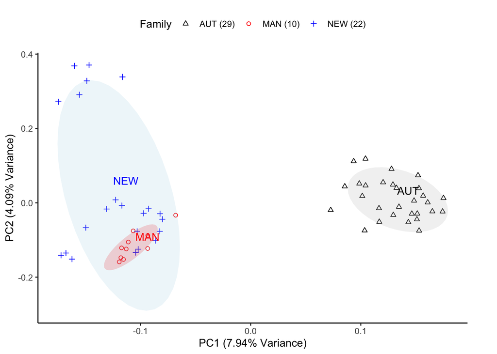

```r
# source the plotting function
source(here("scripts", "analysis", "my_theme2.R"))

# Shapes
N = 100
M = 1000
good.shapes = c(1:25, 33:127)

# Colors
palette1 <- brewer.pal(12, "Paired")
palette2 <- brewer.pal(11, "Set3")
palette23 <- c(palette1, palette2)

# Compute the count
family_count <- pca |>
  group_by(X.FID) |>
  summarize(count = n())

# Merge the count back to the main data
df4 <- pca |>
  left_join(family_count, by = "X.FID")

# Create a custom label for the legend
df4$family_label <-
  paste(df4$X.FID, " (", df4$count, ")", sep = "")

# Define the color and shape manually
palette23 <- c(palette1, palette2)
colors <- setNames(palette23, unique(df4$family_label))
shapes <-
  setNames(good.shapes[c(1:25, 58:67)], unique(df4$family_label))


# Compute the center of ellipses for each continent
ellipse_centers <- df4 |>
  group_by(X.FID) |>
  summarise(PC1_center = mean(PC1), PC2_center = mean(PC2))

# Create the plot
ggplot(df4, aes(PC1, PC2)) +
  geom_point(aes(shape = family_label, color = family_label)) +
  stat_ellipse(
    aes(fill = X.FID, group = X.FID),
    geom = "polygon",
    alpha = 0.2,
    level = 0.8,
    segments = 40,
    color = "transparent",
    show.legend = FALSE
  ) +
  # stat_ellipse(
  #   aes(group = X.FID),
  #   geom = "path",
  #   level = 0.8,
  #   segments = 40,
  #   color = "transparent"
  # ) +
  geom_text_repel(
    data = ellipse_centers,
    aes(x = PC1_center, y = PC2_center, label = X.FID),
    color = c("black", "red", "blue")
  ) +
  xlab("PC1 (7.94% Variance)") +
  ylab("PC2 (4.09% Variance)") +
  # labs(caption = "Principal Component Analysis with 110,353 SNPs.") +
   guides(
  color = guide_legend(title = "Family", order = 1, ncol = 3),
  shape = guide_legend(title = "Family", order = 1, ncol = 3),
  fill = guide_legend(title = "Family", order = 1, ncol = 3)
  ) +
  scale_fill_manual(values = c("gray", "red", "lightblue"), labels = df4$family_label) +
  scale_color_manual(values = c("black", "red", "blue")) +
  scale_shape_manual(values = shapes) +
  # my_theme() +
  theme_classic() +
  theme(
    plot.caption = element_text(face = "italic"),
    legend.position = "top",
    legend.direction = "horizontal",
    legend.justification = "center",
    legend.box.just = "center",
    legend.box.background = element_blank(),
    plot.margin = margin(5.5, 30, 5.5, 5.5, "points"),
    legend.margin = margin(10, 10, 10, 10)
)
```

```r
#   ____________________________________________________________________________
#   save the pca plot                                                       ####
ggsave(
  here(
    "output", "quality_control", "figures", "PCA_plink.pdf"
  ),
  width  = 7,
  height = 5,
  units  = "in"
)
```

## 4. Create chromosomal scale

Import the .bim file with the SNPs to create a new chromosomal scale.

```r
#   ____________________________________________________________________________
#   import the bim file with the SNP data                                   ####
snps <-
  read_delim(                    # to learn about the options use here, run ?read_delim on the console.
    here(
      "output", "quality_control", "file7.bim"
    ),                           # use library here to load it
    col_names      = FALSE,      # we don't have header in the input file
    show_col_types = FALSE,      # suppress message from read_delim
    col_types      = "ccidcc"    # set the class of each column
  )
#
# set column names
colnames(
  snps
) <-                             # to add a header in our tibble
  c(
    "Scaffold", "SNP", "Cm", "Position", "Allele1", "Allele2"
  )
#
# check the tibble
head(snps)
```

```
## # A tibble: 6 × 6
##   Scaffold SNP             Cm Position Allele1 Allele2
##   <chr>    <chr>        <int>    <dbl> <chr>   <chr>
## 1 1.1      AX-581444870     0    97856 C       T
## 2 1.1      AX-583035083     0   305518 A       G
## 3 1.1      AX-583035102     0   308124 A       G
## 4 1.1      AX-583033342     0   315059 C       G
## 5 1.1      AX-583035163     0   315386 A       G
## 6 1.1      AX-583033356     0   315674 C       T
```

We can write a function to import the bim files.

```r
#   ____________________________________________________________________________
#   function to import bim files                                            ####
#
import_bim <- function(file) {
  # import as a tibble and set columns as integers
  bim <-
    read_delim(
      file,
      col_names      = FALSE,
      show_col_types = FALSE,
      col_types      = "ccidcc"
    )
  # rename the columns by index
  bim <- bim |>
    rename(
      Scaffold = 1,
      SNP      = 2,
      Cm       = 3,
      Position = 4,
      Allele1  = 5,
      Allele2  = 6
    )
  return(bim)
}
# we can save the function to source it later
dump(                                                     # check ?dump for more information
  "import_bim",                                           # the object we want to save
  here(
    "scripts", "analysis", "import_bim.R")       # use here to save it our function as .R
)
```

Separate the tibbles into each chromosome.

```r
#   ____________________________________________________________________________
#   separate the SNP data per chromosome                                    ####
# chr1
chr1_snps <-
  snps |>
  filter(
    str_detect(
      Scaffold, "^1."
    )
  ) |> # here we get only Scaffold rows starting with 1
  as_tibble() # save as tibble
#
# chr2
chr2_snps <-
  snps |>
  filter(
    str_detect(
      Scaffold, "^2."
    )
  ) |>
  as_tibble()
#
# chr3
chr3_snps <-
  snps |>
  filter(
    str_detect(
      Scaffold, "^3."
    )
  ) |>
  as_tibble()
```

Now we can index the reference genome with the new scaffold names that match our .bim file

```bash
# index the genome
samtools faidx data/genome/albo.fasta.gz
```

Transfer genome to the cluster.

```bash
# change the paths to match your directories
rsync -chavzP --stats /Users/lucianocosme/Dropbox/Albopictus/manuscript_chip/data/no_autogenous/albo_chip/data/genome/* lvc26@ruddle.hpc.yale.edu:/ycga-gpfs/project/caccone/lvc26/albo_manuscript/updated_genome
```

Now we can get the scaffold order and their size from the `.fai` file. Check the about it at `Samtools` documentation [HERE](http://www.htslib.org/doc/faidx.html).

```bash
# check the head of the .fai file
head data/genome/albo.fasta.gz.fai
# For each row:
# Column 1: The scaffold name. In your FASTA file, this is preceded by '>'
# Column 2: The number of bases in the scaffol
# Column 3: The byte index of the file where the scaffold sequence begins.
# Column 4: bases per line in the FASTA file
# Column 5: bytes per line in the FASTA file
#
# we can use awk to get the first two columns, I also change the field separator.
cat data/genome/albo.fasta.gz.fai | awk 'BEGIN{FS=" "; OFS="\t"} {print $1, $2}' > data/genome/scaffold_sizes.txt;
echo "scaffold sizes";
# check the output
head data/genome/scaffold_sizes.txt
# since we fixed the scaffold order previous, and also moved the scaffold 1.86 to its correct position, we can move ahead and calculate the new scale for our SNPs.
```

Import the file with sizes of each scaffold.

```r
#   ____________________________________________________________________________
#   import the file with the scaffold sizes                                 ####
sizes <-
  read_delim(
    here(
      "data", "genome", "scaffold_sizes.txt"
    ),
    col_names      = FALSE,
    show_col_types = FALSE,
    col_types      = "cd"
  )
#
# set column names
colnames(
  sizes
) <- c(
  "Scaffold", "Size"
)
#   ____________________________________________________________________________
#   create new column with the chromosome number                            ####
sizes <-
  sizes |>
  mutate(
    Chromosome = case_when( # we use mutate to create a new column called Chromosome
      startsWith(
        Scaffold, "1"
      ) ~ "1", # use startsWith to get Scaffold rows starting with 1 and output 1 on Chromosome column
      startsWith(
        Scaffold, "2"
      ) ~ "2",
      startsWith(
        Scaffold, "3"
      ) ~ "3"
    )
  ) |>
  arrange(
    Scaffold
  )                   # to sort the order of the scaffolds, fixing the problem we have with scaffold 1.86
# check it
head(sizes)
```

```
## # A tibble: 6 × 3
##   Scaffold     Size Chromosome
##   <chr>       <dbl> <chr>
## 1 1.1        351198 1
## 2 1.10     11939576 1
## 3 1.100     3389100 1
## 4 1.101      470438 1
## 5 1.102     2525157 1
## 6 1.103      150026 1
```

Create new scale. Get the scaffolds for each chromosome.

```r
#   ____________________________________________________________________________
#   separate the scaffold sizes tibble per chromosome                       ####
# chr1
chr1_scaffolds <-
  sizes |>
  filter(
    str_detect(
      Scaffold, "^1" # we use library stringr to get scaffolds starting with 1 (chromosome 1)
    )
  ) |>
  as_tibble()
#
# chr2
chr2_scaffolds <-
  sizes |>
  filter(
    str_detect(
      Scaffold, "^2" # we use library stringr to get scaffolds starting with 2 (chromosome 2)
    )
  ) |>
  as_tibble()
#
# # chr3
chr3_scaffolds <-
  sizes |>
  filter(
    str_detect(
      Scaffold, "^3" # we use library stringr to get scaffolds starting with 3 (chromosome 3)
    )
  ) |>
  as_tibble()
```

Create a scale for each chromosome.

```r
#   ____________________________________________________________________________
#   create a new scale for each chromosome                                  ####
# chr1
chr1_scaffolds$overall_size_before_bp <-
  0                                                                        # we create a new column with zeros
for (i in 2:nrow(
  chr1_scaffolds
)
) {                                                                        # loop to start on second line
  chr1_scaffolds$overall_size_before_bp[i] <-                              # set position on the scale
    chr1_scaffolds$overall_size_before_bp[i - 1] + chr1_scaffolds$Size[i - # add the scaffold size and the location to get position on new scale
      1]
}
#
# chr2
chr2_scaffolds$overall_size_before_bp <- 0
for (i in 2:nrow(
  chr2_scaffolds
)
) {
  chr2_scaffolds$overall_size_before_bp[i] <-
    chr2_scaffolds$overall_size_before_bp[i - 1] + chr2_scaffolds$Size[i -
      1]
}
#
# chr3
chr3_scaffolds$overall_size_before_bp <- 0
for (i in 2:nrow(
  chr3_scaffolds
)
) {
  chr3_scaffolds$overall_size_before_bp[i] <-
    chr3_scaffolds$overall_size_before_bp[i - 1] + chr3_scaffolds$Size[i -
      1]
}
```

Merge the data frames scaffolds and SNPs.

```r
#   ____________________________________________________________________________
#   merge the data sets using the tidyverse function left_join              ####
# chr1
chr1_scale <-
  chr1_snps |>          # create data frame for each chromosome, get chr1_snps
  left_join(            # use lef_join function to merge it with chr1_scaffolds
    chr1_scaffolds,
    by = "Scaffold"
  ) |>                  # set column to use for merging (Scaffold in this case)
  na.omit() |>          # remove NAs, we don't have SNPs in every scaffold
  mutate(
    midPos_fullseq = as.numeric(
      Position
    ) +                 # make new columns numeric
      as.numeric(
        overall_size_before_bp
      )
  )
#
# chr2
chr2_scale <-
  chr2_snps |>
  left_join(
    chr2_scaffolds,
    by = "Scaffold"
  ) |>
  na.omit() |>
  mutate(
    midPos_fullseq = as.numeric(
      Position
    ) +
      as.numeric(
        overall_size_before_bp
      )
  )
#
# chr3
chr3_scale <-
  chr3_snps |>
  left_join(
    chr3_scaffolds,
    by = "Scaffold"
  ) |>
  na.omit() |>
  mutate(
    midPos_fullseq = as.numeric(
      Position
    ) +
      as.numeric(
        overall_size_before_bp
      )
  )
```

Merge all chromosome scales.

```r
#   ____________________________________________________________________________
#   merge the data sets, and select only the columns we need                ####
chroms <- rbind(
  chr1_scale, chr2_scale, chr3_scale
) |>
  dplyr::select(
    Chromosome, SNP, Cm, midPos_fullseq, Allele1, Allele2
  )
# check it
head(chroms)
```

```
## # A tibble: 6 × 6
##   Chromosome SNP             Cm midPos_fullseq Allele1 Allele2
##   <chr>      <chr>        <int>          <dbl> <chr>   <chr>
## 1 1          AX-581444870     0          97856 C       T
## 2 1          AX-583035083     0         305518 A       G
## 3 1          AX-583035102     0         308124 A       G
## 4 1          AX-583033342     0         315059 C       G
## 5 1          AX-583035163     0         315386 A       G
## 6 1          AX-583033356     0         315674 C       T
```

Save the new .bim file

```r
#   ____________________________________________________________________________
#   save the new bim file with a new name, I added "B"                      ####
write.table(
  chroms,
  file      = here(
    "output", "quality_control", "file7B.bim"
  ),
  sep       = "\t",
  row.names = FALSE,
  col.names = FALSE,
  quote     = FALSE
)
```

Rename the .bim files

```bash
# change the name of the first .bim file, for example, append _backup.bim, and then replace the original file
mv output/quality_control/file7.bim output/quality_control/file7_backup.bim;
# than change the new bim we create to the original name (do it only once, otherwise it will mess up)
mv output/quality_control/file7B.bim output/quality_control/file7.bim
```

Create a new bed file with Plink2 to see if it works. For example, to see if the variants are in the right order. Plink2 will give us a warning.

```bash
plink2 \
--bfile output/quality_control/file7 \
--make-bed \
--out output/quality_control/test01;
# then we remove the files
rm output/quality_control/test01.*
```

[output not shown]

No warnings from Plink2. Now, we can go ahead with our analysis.

## 5. Plot SNP density

```r
# load the function that we saved earlier
source(
  here(
    "scripts", "analysis", "import_bim.R"
  ),
  local = knitr::knit_global()
)
# import the file
snp_den_qc <- import_bim(
  here(
    "output", "quality_control", "file7.bim"
  )
)
```

Make plot of the SNP density

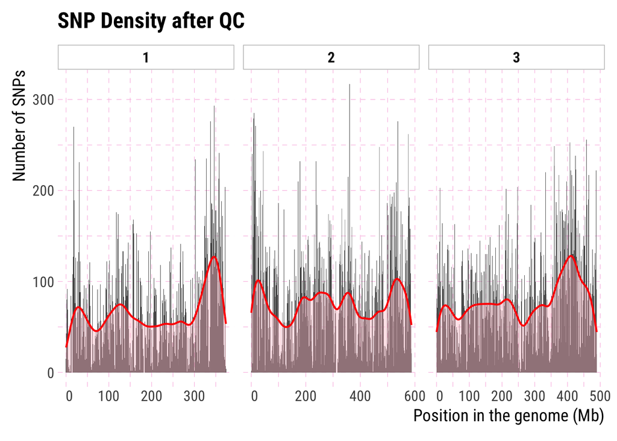

```r
#   ____________________________________________________________________________
#   plot SNP density after QC                                               ####
snp_den_qc |>
  rename(
    Chromosome = 1
  ) |>
  mutate(
    Position           = as.numeric(
      Position
    )
  ) |>
  ggplot(
    aes(
      x                = Position
    ),
    label              = sprintf(
      "%0.2f",
      round(
        a,
        digits         = 0
      )
    )
  ) +
  geom_histogram(
    aes(
      y                = after_stat(
        count
      )
    ),
    binwidth           = 1e6
  ) +
  facet_wrap(
    vars(
      Chromosome
    ),
    scales             = "free_x"
  ) +
  labs(
    title              = "SNP Density after QC",
    x                  = expression(
      "Position in the genome (Mb)"
    ),
    y                  = expression(
      "Number of SNPs"
    )
  ) +
  scale_x_continuous(
    labels             = function(x) {
      format(
        x / 1e6,
        big.mark       = ",",
        scientific     = FALSE
      )
    }
  ) +
  geom_density(
  aes(
    y = 1e6 * after_stat(count)
  ),
  color = "red",
  linewidth = .75,
  alpha = .4,
  fill = "pink"
  ) +
  hrbrthemes::theme_ipsum(
    base_family        = "Roboto Condensed",
    axis_text_size     = 12,
    axis_title_size    = 14,
    plot_margin        = margin(
      10, 10, 10, 10
    ),
    grid               = TRUE,
    grid_col           = "#fabbe2"
  ) +
  theme(
    panel.grid.major   = element_line(
      linetype         = "dashed",
      linewidth        = 0.2
    ),
    panel.grid.minor   = element_line(
      linetype         = "dashed",
      linewidth        = 0.2
    ),
    panel.spacing      = unit(0.5, "lines"),
    strip.text         = element_text(
      face             = "bold", hjust = .5
    ),
    strip.background.x = element_rect(
      color            = "gray"
    )
  )
```

```r
#   ____________________________________________________________________________
#   save the density plot                                            ####
ggsave(
  here(
    "output", "quality_control","figures", "snp_density_after_qc.pdf"
  ),
  width  = 10,
  height = 6,
  units  = "in"
)
```

SNPs per chromosome

```r
# we can use dplyr "count" to get the number of SNPs for each chromosome
# lets get the data we need
snps_per_chrm <-
  snp_den_qc |>
  count(
    Scaffold) |>
  rename(
    Chromosome = 1,
    "SNPs (N) " = 2
  )

# Create the flextable
ft <- flextable::flextable(snps_per_chrm)

# Apply zebra theme
ft <- flextable::theme_zebra(ft)

# Add a caption to the table
ft <- flextable::add_header_lines(ft, "SNPs per chromosome after quality control")
ft
```

| SNPs per chromosome after quality control Chromosome | SNPs per chromosome after quality control SNPs (N) |
| --- | --- |
| 1 | 25,105 |
| 2 | 45,902 |
| 3 | 39,346 |

We can get the mean number of SNPs per chromosome or the entire genome

```r
# we first use dplyr cut_width to get the number of SNPs per 1Mb window
albo_den <-
  snp_den_qc |>
  dplyr::select(
    Scaffold, Position
  ) |>
  group_by(
    Scaffold,
    windows               = cut_width(
      Position,
      width               = 1e6,
      boundary            = 0
    )
  ) |>
  summarise(
    n                     = n(),
    .groups               = "keep"
  ) |>
  group_by(
    Scaffold
  ) |>
  summarise(
    mean                  = mean(n),
    n                     = n(),
    .groups               = "keep"
  ) |>
  rename(
    Chromosome            = 1,
    "SNPs per 1Mb window" = 2,
    "Number of windows"   = 3
  )
#
# check the results
snp_table <-
  flextable(
    albo_den
  )
snp_table <- colformat_double(
  x        = snp_table,
  big.mark = ",",
  digits   = 2,
  na_str   = "N/A"
)
snp_table
```

| Chromosome | SNPs per 1Mb window | Number of windows |
| --- | --- | --- |
| 1 | 67.85 | 370 |
| 2 | 79.01 | 581 |
| 3 | 80.46 | 489 |

Merge objects

```r
# we can merge the two data sets we created above into one table
after_qc <-
  snps_per_chrm |>
  left_join(
    albo_den,
    by = "Chromosome"
  )
snp_table2 <- flextable(
  after_qc)
snp_table2 <- colformat_double(
  x        = snp_table2,
  big.mark = ",",
  digits   = 2,
  na_str   = "N/A"
  )
snp_table2
```

| Chromosome | SNPs (N) | SNPs per 1Mb window | Number of windows |
| --- | --- | --- | --- |
| 1 | 25,105 | 67.85 | 370 |
| 2 | 45,902 | 79.01 | 581 |
| 3 | 39,346 | 80.46 | 489 |